# Assignment 4 STATS 369

Anish Hota

2025-10-17

## Setup

```r
library(tidyverse)
library(lubridate)
library(janitor)
library(caret)
library(randomForest)
library(xgboost)
student_id <- 427632295
set.seed(student_id)
```

## Task 1

# Loading Data

```r
data_raw <- read_rds('nz_birds_tui_bell.rds')
glimpse(data_raw)
```

```
## Rows: 173,723
## Columns: 50
## $ gbifID                           <dbl> 5383817269, 4822289646, 3550558766, 3…
## $ datasetKey                       <chr> "4fa7b334-ce0d-4e88-aaae-2e0c138d049e…
## $ occurrenceID                     <chr> "URN:catalog:CLO:EBIRD_ATL_NZ:OBS2169…
## $ kingdom                          <chr> "Animalia", "Animalia", "Animalia", "…
## $ phylum                           <chr> "Chordata", "Chordata", "Chordata", "…
## $ class                            <chr> "Aves", "Aves", "Aves", "Aves", "Aves…
## $ order                            <chr> "Passeriformes", "Passeriformes", "Pa…
## $ family                           <chr> "Meliphagidae", "Meliphagidae", "Meli…
## $ genus                            <chr> "Prosthemadera", "Prosthemadera", "Pr…
## $ species                          <chr> "Prosthemadera novaeseelandiae", "Pro…
## $ infraspecificEpithet             <lgl> NA, NA, NA, NA, NA, NA, NA, NA, NA, N…
## $ taxonRank                        <chr> "SPECIES", "SPECIES", "SPECIES", "SPE…
## $ scientificName                   <chr> "Prosthemadera novaeseelandiae (J.F.G…
```

[output cut: 37 more lines]

# Variables With no Variation

```r
zero_var_cols <- data_raw |>
select(where(~ n_distinct(., na.rm = TRUE) <= 1)) |>
names()
zero_var_cols
```

```
##  [1] "datasetKey"                       "kingdom"
##  [3] "phylum"                           "class"
##  [5] "order"                            "family"
##  [7] "infraspecificEpithet"             "taxonRank"
##  [9] "verbatimScientificNameAuthorship" "countryCode"
## [11] "occurrenceStatus"                 "publishingOrgKey"
## [13] "coordinateUncertaintyInMeters"    "coordinatePrecision"
## [15] "elevation"                        "elevationAccuracy"
## [17] "depth"                            "depthAccuracy"
## [19] "basisOfRecord"                    "institutionCode"
## [21] "recordNumber"                     "identifiedBy"
## [23] "dateIdentified"                   "license"
## [25] "rightsHolder"                     "typeStatus"
## [27] "establishmentMeans"               "mediaType"
```

# Proportion of Value Missing For Each Variable

```r
missing_prop <- data_raw |>
summarise(across(everything(), ~ mean(is.na(.)))) |>
pivot_longer(everything(), names_to = 'variable', values_to = 'prop_missing') |>
arrange(desc(prop_missing))
missing_prop
```

```
## # A tibble: 50 × 2
##    variable                         prop_missing
##    <chr>                                   <dbl>
##  1 infraspecificEpithet                        1
##  2 verbatimScientificNameAuthorship            1
##  3 coordinateUncertaintyInMeters               1
##  4 coordinatePrecision                         1
##  5 elevation                                   1
##  6 elevationAccuracy                           1
##  7 depth                                       1
##  8 depthAccuracy                               1
##  9 recordNumber                                1
## 10 identifiedBy                                1
## # ℹ 40 more rows
```

# Other Quality Issues

There seems to be some variables with the same or very similar values to one another, which means that some of these columns are just not necessary for further investigation.

# Cleaning the Data

```r
birds <- data_raw

# Remove zero-variance variables
if(length(zero_var_cols) > 0) birds <- birds |>
  select(-all_of(zero_var_cols))

# Exclude irrelevant / duplicate variables
birds <- birds |>
  select(-all_of(c("genus","scientificName","verbatimScientificName", "taxonKey", "collectionCode", "issue","lastInterpreted","speciesKey")))

# Restricting with NZ boundaries
birds <- birds |>
filter(
between(decimalLatitude, -50, -33) &
between(decimalLongitude, 166, 180)
)

# Imputing missing values
birds[is.na(birds)] <- 0

# Creating new response variable
birds <- birds |>
mutate(is_bellbell = species == 'Anthornis melanura')
birds
```

```
## # A tibble: 172,780 × 15
##        gbifID occurrenceID        species locality stateProvince individualCount
##         <dbl> <chr>               <chr>   <chr>    <chr>                   <dbl>
##  1 5383817269 URN:catalog:CLO:EB… Prosth… Inglewo… Taranaki                    1
##  2 4822289646 URN:catalog:CLO:EB… Prosth… Doon St… Otago                       1
##  3 3550558766 URN:catalog:CLO:EB… Prosth… approx … Northland                   1
##  4 3594829865 URN:catalog:CLO:EB… Prosth… Grindst… Otago                       1
##  5 4625153740 URN:catalog:CLO:EB… Anthor… Flea Ba… Canterbury                  1
##  6 3213777787 URN:catalog:CLO:EB… Prosth… 930 Pur… Waikato                     3
##  7 3271965325 URN:catalog:CLO:EB… Prosth… Parewan… Manawatu-Wan…               1
##  8 4807538616 URN:catalog:CLO:EB… Anthor… Pryces … Manawatu-Wan…               2
##  9 5557407548 URN:catalog:CLO:EB… Prosth… Shipbui… Southland                   1
## 10 5422540923 URN:catalog:CLO:EB… Anthor… Brook W… Nelson                     10
## # ℹ 172,770 more rows
## # ℹ 9 more variables: decimalLatitude <dbl>, decimalLongitude <dbl>,
## #   eventDate <date>, day <dbl>, month <dbl>, year <dbl>, catalogNumber <chr>,
## #   recordedBy <chr>, is_bellbell <lgl>
```

## Task 2

# Regions of NZ Showing the Greatest Prescence of Bellbirds

```r
region_tab <- birds |>
group_by(stateProvince, is_bellbell) |>
summarise(n_obs = n(), .groups = 'drop') |>
group_by(stateProvince) |>
mutate(prop_bellbird = n_obs / sum(n_obs)) |>
filter(is_bellbell == TRUE) |>
arrange(desc(n_obs))
region_tab
```

```
## # A tibble: 16 × 4
## # Groups:   stateProvince [16]
##    stateProvince     is_bellbell n_obs prop_bellbird
##    <chr>             <lgl>       <int>         <dbl>
##  1 Canterbury        TRUE        11960         0.936
##  2 Otago             TRUE         8543         0.657
##  3 Southland         TRUE         8016         0.574
##  4 Wellington        TRUE         7932         0.254
##  5 Marlborough       TRUE         6705         0.687
##  6 West Coast        TRUE         5755         0.620
##  7 Manawatu-Wanganui TRUE         5611         0.291
##  8 Tasman            TRUE         5221         0.607
##  9 Waikato           TRUE         2877         0.230
## 10 Auckland          TRUE         2816         0.126
## 11 Nelson            TRUE         1680         0.502
## 12 Bay of Plenty     TRUE         1277         0.273
## 13 Hawke's Bay       TRUE          872         0.361
## 14 Taranaki          TRUE          662         0.186
## 15 Northland         TRUE          634         0.125
## 16 Gisborne          TRUE          333         0.351
```

Regions such as Canterbury, Southland and Otago seem to have a lot of Bellbirds, where areas like Gisborne, Taranaki and Northland seem to not have as much. In general it seems that Bellbirds are more towards the south of NZ rather than the North.

# Number of Birds Recorded per Encounter Between Species

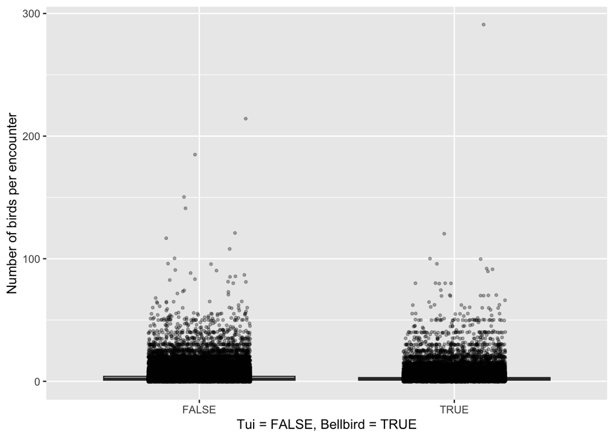

```r
ggplot(birds, aes(x = as.factor(is_bellbell), y = individualCount)) +
geom_boxplot(outlier.shape = NA) +
geom_jitter(width = 0.2, alpha = 0.3, size = 0.8) +
labs(x = 'Tui = FALSE, Bellbird = TRUE', y = 'Number of birds per encounter')
```

No there is no significant difference of individual count between the two species.

# Trends by Month Between Species

```r
monthly_trends <- birds |>
  mutate(date = as.Date(paste(year, month, "01", sep = "-"))) |>
  group_by(is_bellbell, year, month) |>
  summarise(total_birds = sum(individualCount, na.rm = TRUE))
```

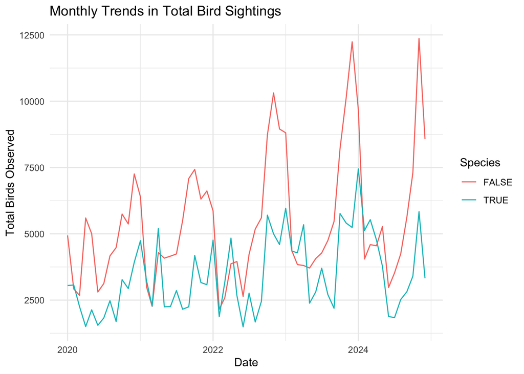

```r
ggplot(monthly_trends, aes(x = as.Date(paste(year, month, "01", sep = "-")),
                           y = total_birds,
                           color = is_bellbell)) +
  geom_line() +
  labs(title = "Monthly Trends in Total Bird Sightings",
       x = "Date",
       y = "Total Birds Observed",
       color = "Species") +
  theme_minimal()
```

It Seems that Tuis are not observed as much in earlier months of the year while bellbirds are similar, but not as much of a difference. This is is probably due to winter months being cold so they are not out and about as much.

## Task 3

# Train/Test + Random Forest Model

```r
# Train/Test Split Data
birds$is_bellbell <- as.factor(birds$is_bellbell)
set.seed(student_id)
idx <- createDataPartition(birds$is_bellbell, p = 0.7, list = FALSE)
train <- birds[idx, ]
test <- birds[-idx, ]

# Random Forest Model
exclude_vars <- c('occurenceID','gbifID','species','is_bellbell','event_date')
exclude_vars <- intersect(exclude_vars, names(train))
predictors <- setdiff(names(train), exclude_vars)
rf_formula <- as.formula(paste('is_bellbell ~', paste(predictors, collapse = ' + ')))
set.seed(student_id)
rf_model <- randomForest(rf_formula, data = train, importance = TRUE, na.action = na.omit)
rf_model
```

```
##
## Call:
##  randomForest(formula = rf_formula, data = train, importance = TRUE,      na.action = na.omit)
##                Type of random forest: classification
##                      Number of trees: 500
## No. of variables tried at each split: 3
##
##         OOB estimate of  error rate: 23.97%
## Confusion matrix:
##       FALSE  TRUE class.error
## FALSE 57482 13839   0.1940382
## TRUE  15156 34470   0.3054044
```

```r
rf_imp <- importance(rf_model)
rf_imp_df <- as.data.frame(rf_imp) |>
  rownames_to_column('variable') |>
  arrange(desc(MeanDecreaseGini))
rf_imp_df
```

```
##            variable     FALSE      TRUE MeanDecreaseAccuracy MeanDecreaseGini
## 1  decimalLongitude  55.64131  55.22288             82.87595       11757.9597
## 2   decimalLatitude  49.43470  93.49183             93.33281       10635.5499
## 3      occurrenceID  55.94972  79.50817             94.66086        5570.5972
## 4     catalogNumber  58.21434  65.15799             91.31776        5186.3194
## 5          locality  29.58112  86.21010             89.09606        4963.6786
## 6   individualCount 223.00812 255.17615            281.64302        3577.2095
## 7     stateProvince  51.12543  37.88547             57.30615        3519.9702
## 8         eventDate  69.13543  65.13851            106.91664        3436.4903
## 9        recordedBy  34.84724  59.45006             58.78412        3314.3605
## 10              day  -1.07337  40.60203             31.42488        2993.7267
## 11            month  37.74461  54.36030             62.27728        1681.0394
## 12             year  25.01556  28.52002             43.53525         498.2598
```

```r
rf_pred <- predict(rf_model, newdata = test)
cm_rf <- confusionMatrix(rf_pred, test$is_bellbell)
```

# XGB Model

Unable to do xgb model.

## Task 4

# Important Variables

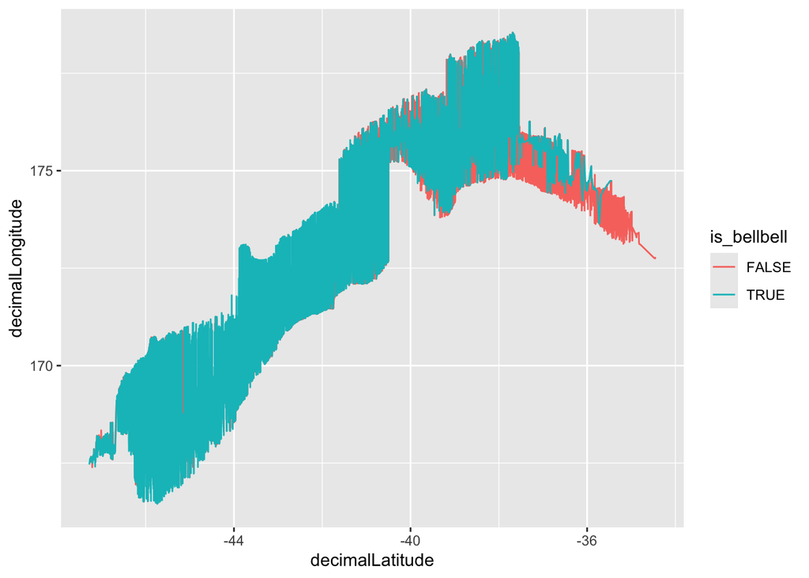

```r
ggplot(birds, aes(x = decimalLatitude, y = decimalLongitude, color = is_bellbell))+
  geom_line()
```

The longitude and latitude variables were deemed the most important so I compared the two together, with the species as the colour. The third most important variable was the occurence_id, which I couldn’t create anything out of because this variable is just a unique id for every single observation.

# Discussion

There will be some observer bias, such as time of day and location they are in as well. The bellbirds might be more prominent in these observers location than normal and also Tuis might also be more aggressive towards feeders and avoid them altogether, which lessens the amount of time they get reported. This sampling bias reflects observer behaviour rather than the ecology of the different species it can give a whole new persepctive to how these species relate to one another.

## Citations and Acknowldgements

I tried many times to do the xgboost model but was unable to figure it out. I have used ChatGPT to help with solving the xgboost model as well as using it to help with the random forest model.